# STATS 531 Final Project

Analysis on Nasdaq-100 Index for the Past 5 Years

April 18, 2021

# Project Background and Motivation

The NASDAQ-100 is a stock market index made up of 102 equity securities issued by 100 of the largest non-financial companies listed on the Nasdaq stock market.$^{[1]}$ These non-financial sectors include retail, biotechnology, industrial, technology, health care, and others. It is a modified capitalization-weighted index. The stocks’ weights in the index are based on their market capitalizations. Weighting allows constraints to limit the influence of the largest companies and balance the index with all members.

In this project, we aim to conduct time series analysis on the Nasdaq-100 index from 2016 to 2021. Specifically, we want to explore more about the volatility of the index in order to get a better understanding of the risk of the stock market.

# Data Introduction and Cleaning

The data comes from the official Nasdaq website$^{[1]}$, containing the open, close, highest and lowest prices for the Nasdaq 100 index from April 11, 2016 to April 9, 2021. There are 1259 observations on trading days in this time period.

We calculate the demeaned daily returns for the closing prices of Nasdaq-100 index, with the hope of constructing time series models for it.

```r
# Load the data
historical_data <- read.csv("HistoricalData_1618091005375.csv")
date <- as.Date(historical_data$Date, format = "%m/%d/%Y")
close_price <- historical_data$Close.Last
# Subset data to get date and closing price
data_c <- historical_data[,c(1,2)]
# reverse order so earliest dates come first
data_c <- data_c[seq(nrow(data_c),1),]
# Convert data to a time series object
doy <- strftime("2016-11-04", format = "%j")
data_ts <- ts(rev(data_c[,c(2)]), start = c(2016,as.numeric(doy) ),
              frequency = 365)
returns <- diff(log(data_ts))
dmrt <- returns - mean(returns)
```

# Exploratory Data Analysis

The daily index data (closing price) and the data after log transformation are shown in the time series plot below.

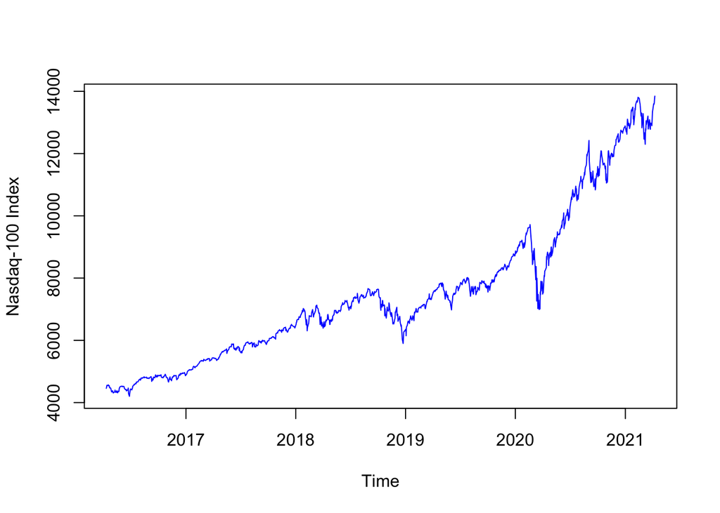

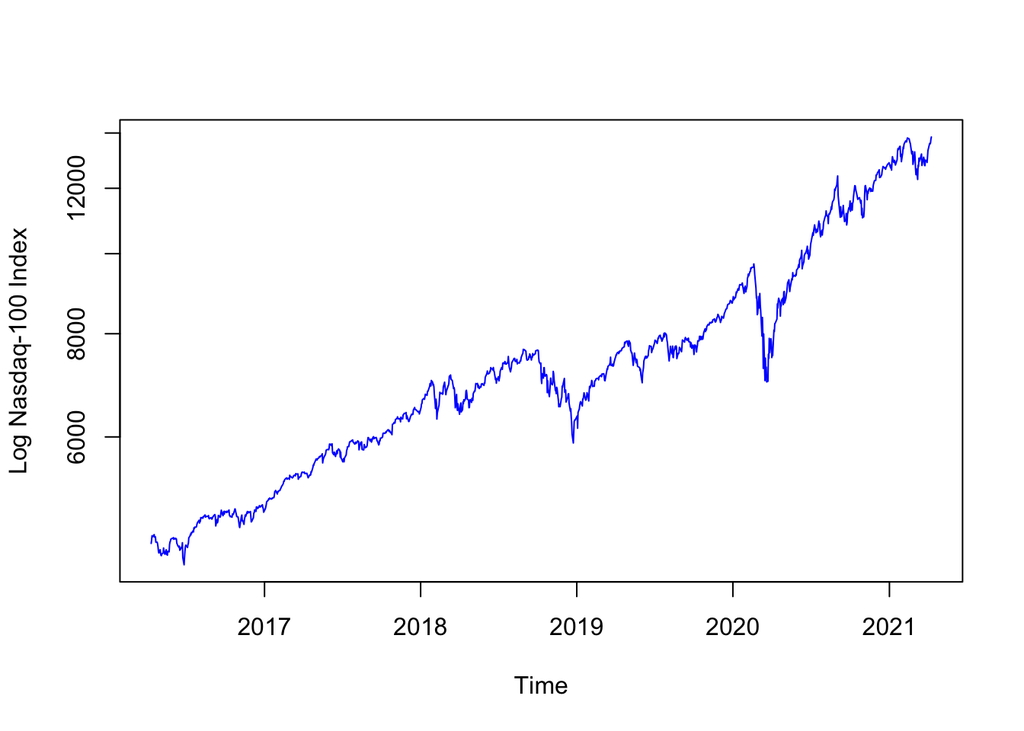

Based on the plots above, we can see that there is an obvious increasing trend for the index. The two sudden drops on the late 2018 and 2020 are due to the financial crisis and the COVID 19.

Usually, we are more interested in the daily returns on a stock market index rather than the exact values. Thus we calculated the return which is the difference of the log of the index and plot them in the figures below:

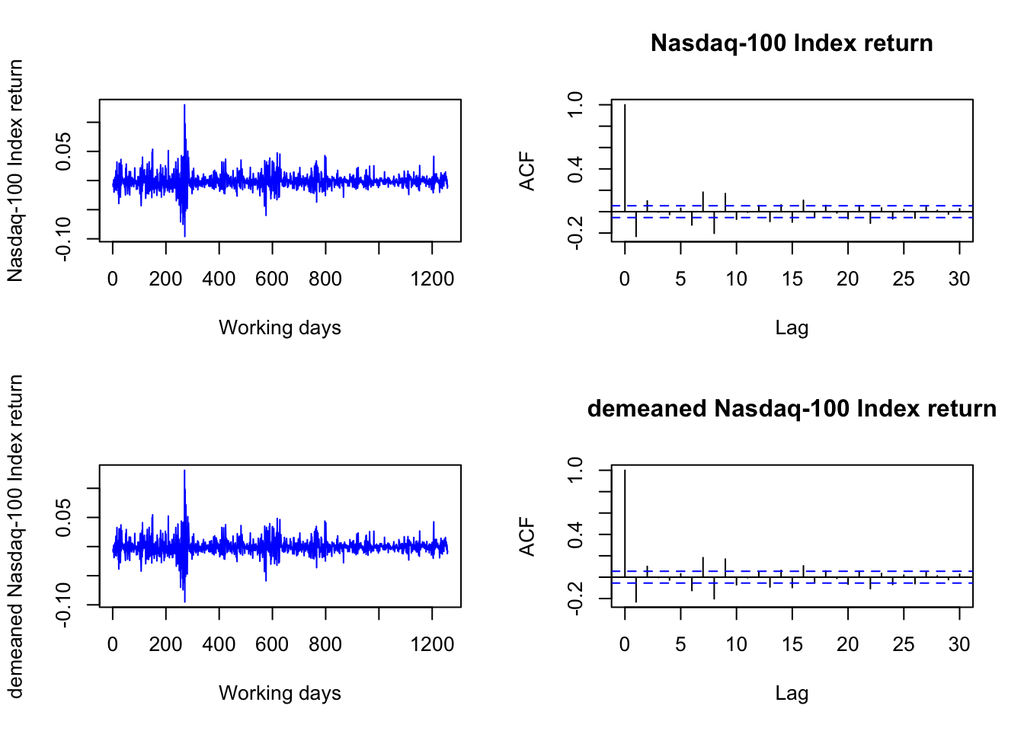

We can see that the log return is almost randomly distributed around 0 and there is almost no difference between the original log return and the demeaned return. Based on the auto correlation plot, there are some evidence for the existence of auto correlation on small order lags up to 2 days. It is reasonable for us to try stationary model to this time series firstly.

# Model Analysis

## ARMA Model

Based on the basic statistical summary and the time series plot, the stationary Gaussian $ARMA(p,q)$ model is used to construct the model under the null hypothesis that there is no trend with the form of:

$$\begin{align*}
\phi(B)(Y_n -\mu) = \psi(B)\varepsilon_n
\end{align*}$$

where

$$\begin{align*}
&\mu = \mathbb{E}[Y_n]\\
&\phi(x) =1 - \phi_1 x - \phi_2 x^2 - \dots - \phi_p x^p\\
&\psi(x) = 1 + \psi_1 x + \psi_2 x^2 + \dots + \psi_q x^q\\
&\varepsilon_{n} \sim iid N(0, \sigma^2)
\end{align*}$$

In order to choose a proper value for p and q, we first tabulate AIC values for a range of different choices of p and q from 0 to 5.

|  | MA0 | MA1 | MA2 | MA3 | MA4 | MA5 |
| --- | --- | --- | --- | --- | --- | --- |
| AR0 | -7141.505 | -7199.711 | -7211.325 | -7209.464 | -7207.987 | -7206.503 |
| AR1 | -7209.050 | -7209.342 | -7209.427 | -7211.638 | -7205.928 | -7204.939 |
| AR2 | -7210.130 | -7208.696 | -7207.553 | -7209.552 | -7227.845 | -7227.753 |
| AR3 | -7209.396 | -7235.882 | -7206.487 | -7261.670 | -7264.906 | -7259.725 |
| AR4 | -7208.372 | -7237.104 | -7233.241 | -7265.137 | -7263.150 | -7270.169 |
| AR5 | -7206.775 | -7204.751 | -7233.127 | -7233.368 | -7265.075 | -7262.179 |

We then check the causality and invertibility of the model. Based on the results, $ARMA(4,3)$ and $ARMA(4,5)$ both suffer from the risk of non-invertibility, as they have MA roots of 1.000003 and 1.002638, respectively. In order to guarantee the invertibility of the model, we finally selected the $ARMA(3,1)$ model. The AR roots are 1.472222, 1.472222, and 4.033999 and the MA root is 1.115911.

```
##
## Call:
## arima(x = dmean_z, order = c(3, 0, 1))
##
## Coefficients:
##           ar1      ar2     ar3     ma1  intercept
##       -1.0989  -0.1275  0.1144  0.8961      0e+00
## s.e.   0.0456   0.0429  0.0294  0.0374      3e-04
##
## sigma^2 estimated as 0.0001842:  log likelihood = 3623.94,  aic = -7235.88
```

```
## [1] 1.472222 1.472222 4.033999
```

```
## [1] 1.115911
```

We then conducted diagnostic plots on the residuals of the selected model:

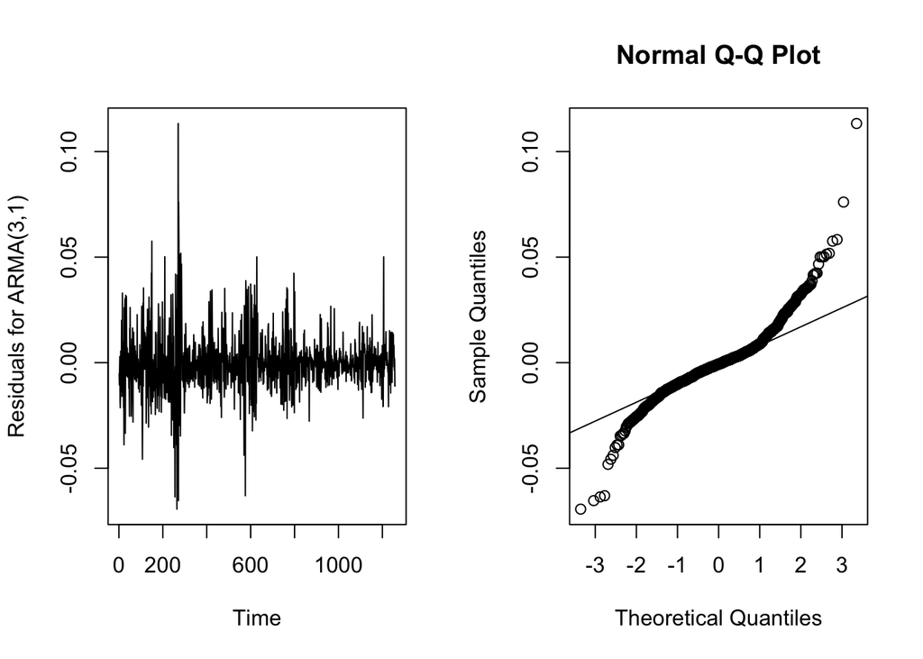

According to the diagnostic plots, the residuals are not similar to Gaussian white noise. QQ-plots shows the distribution of residuals for the model has heavier tails than the normal distribution.

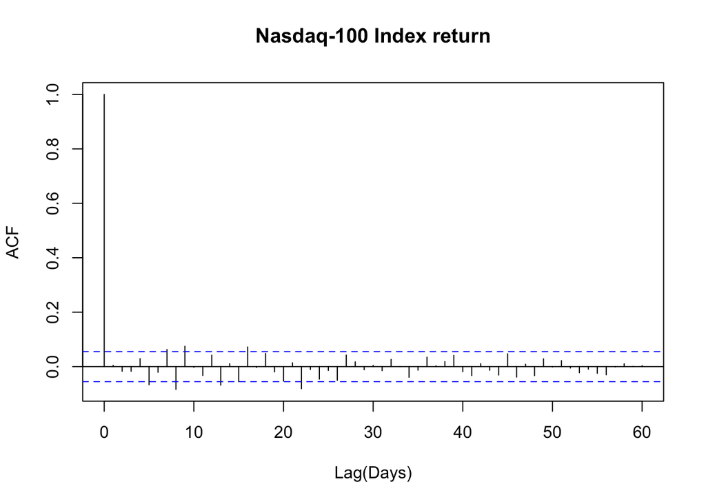

## GARCH Model

In order to better fit our data, we then try to construct a $GARCH(p,q)$ model with the following form:

$$\begin{align*}
Y_{n}=\epsilon_{n} \sqrt{V_{n}}
\end{align*}$$

where

$$\begin{align*}
V_{n}=\alpha_{0}+\sum_{j=1}^p \alpha_j Y_{n-j}^2+\sum_{k=1}^q \beta_k V_{n-k}
\end{align*}$$

and $\epsilon_{n}$ is white noise.

Similarly, in order to choose a proper value for p and q, we first tabulate AIC values for a range of different choices of p and q from 0 to 5.

|  | Q = 1 | Q = 2 | Q = 3 | Q = 4 | Q = 5 |
| --- | --- | --- | --- | --- | --- |
| P = 1 | -7332.532 | -7839.581 | -7831.265 | -7823.350 | -7825.499 |
| P = 2 | -7332.111 | -7834.778 | -7829.616 | -7820.177 | -7813.882 |
| P = 3 | -7332.632 | -7819.960 | -7818.835 | -7813.608 | -7809.507 |
| P = 4 | -7329.548 | -7804.124 | -7806.093 | -7560.798 | -7646.307 |
| P = 5 | -7338.343 | -7460.696 | -7538.082 | -7722.093 | -7796.722 |

According to the AIC table, we noticed that the lowest AIC value -7839.581 is reached when P = 1 and Q = 2. Also, the dimension of this model is also reasonable and has much lower AIC value compared with the simpler $GARCH(1,1)$ model. The parameter estimations given by the $GARCH(1,2)$ model is shown as below:

```
##
## Call:
## garch(x = dmean_z, order = c(1, 2), grad = "numerical", trace = FALSE)
##
## Model:
## GARCH(1,2)
##
## Residuals:
##      Min       1Q   Median       3Q      Max
## -4.74117 -0.66486 -0.07072  0.46634  4.55356
##
## Coefficient(s):
##     Estimate  Std. Error  t value Pr(>|t|)
## a0 6.865e-06   1.236e-06    5.555 2.77e-08 ***
## a1 1.306e-01   3.445e-02    3.792 0.000149 ***
## a2 1.463e-01   4.986e-02    2.934 0.003349 **
## b1 7.025e-01   3.421e-02   20.536  < 2e-16 ***
## ---
## Signif. codes:  0 '***' 0.001 '**' 0.01 '*' 0.05 '.' 0.1 ' ' 1
##
## Diagnostic Tests:
##  Jarque Bera Test
##
## data:  Residuals
## X-squared = 153.34, df = 2, p-value < 2.2e-16
##
##
##  Box-Ljung test
##
## data:  Squared.Residuals
## X-squared = 0.094969, df = 1, p-value = 0.758
```

```
## 'log Lik.' 3923.79 (df=4)
```

The formula of our $GARCH(1,2)$ model is:
$$\begin{align*}
Y_{n}=\epsilon_{n} \sqrt{V_{n}}
\end{align*}$$

where

$$\begin{align*}
V_{n}=6.865*10^{-6}+0.1306Y_{n-1}^2+0.1463Y_{n-2}^2+0.7025V_{n-1}
\end{align*}$$

We can find that the log likelihood of the model is 3923.79 with 4 degrees of freedom for $GARCH(1,2)$. This log likelihood is much higher than that we get from $ARMA(3,1)$ model. All the parameters are significant on 0.01 level.

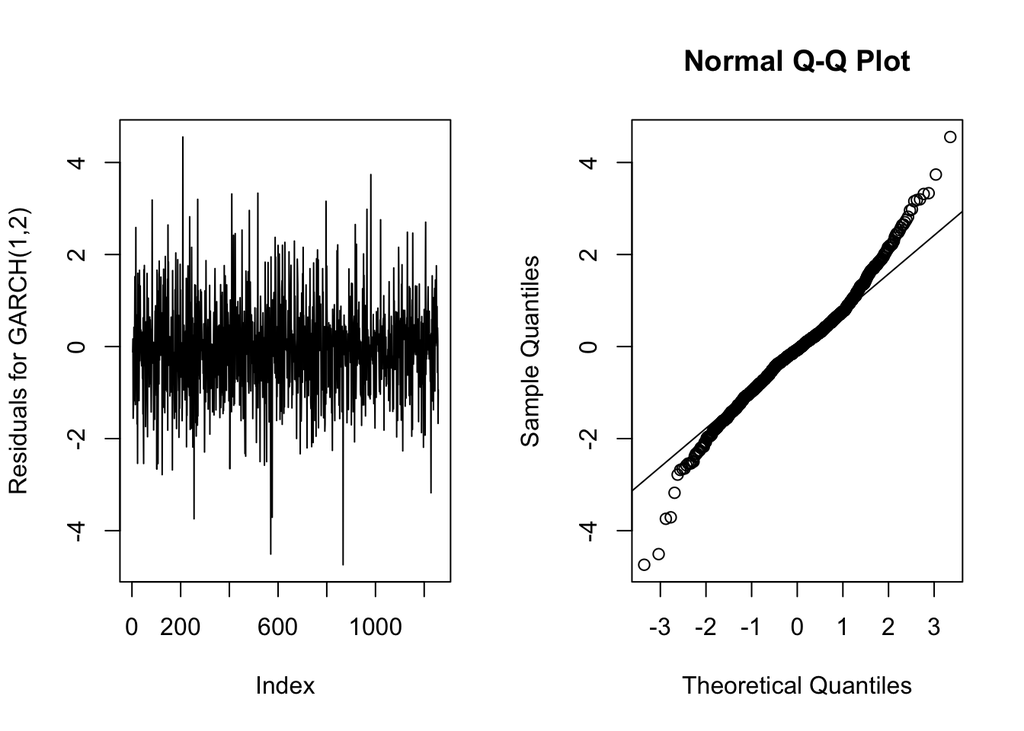

Based on the diagnostics plots, the residuals seem to look like white noise. The QQ-plot shows residuals for the model are still slightly heavier-tailed than the normal distribution, but they are significantly closer to Gaussian than residuals for $ARMA(3,1)$ model. The Jarque-Bera Test on residuals also shows that the assumption of normal distribution error is violated.

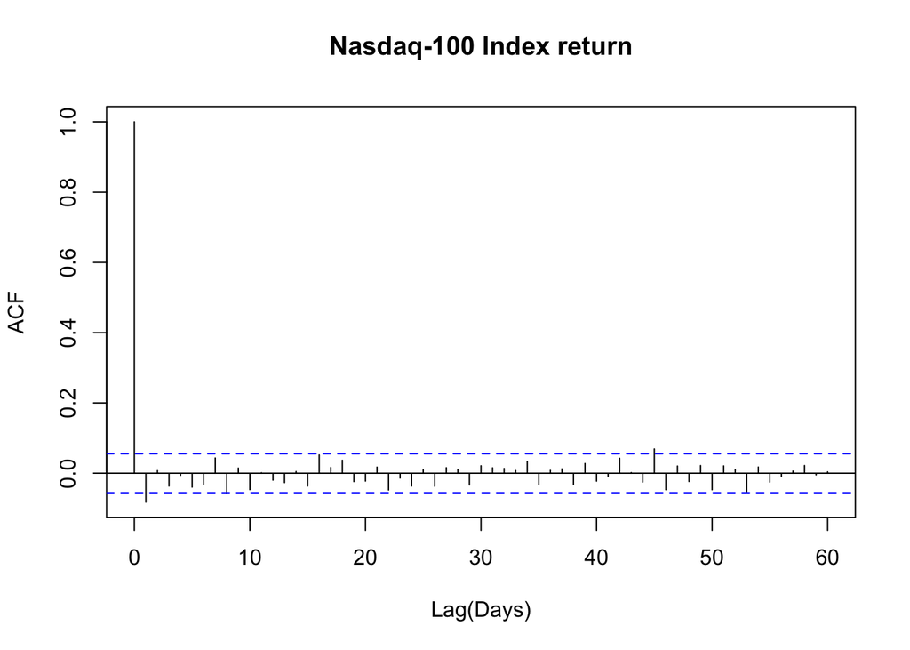

## POMP Model

### Model Structure

We include time-varying variables using the model framework of Breto (2014), which is a modified version of the basic stochastic volatility model:
$$Y_n=exp(H_n/2)\epsilon_n$$
The latent states are
$$H_n = \mu_h(1-\phi)+\phi H_{n-1}+\beta_{n-1}R_nexp(-H_{n-1}/2)+\omega_n \\
G_n = G_{n-1}+v_n$$
where $Y_n$ is the observed time series, $\beta_n=Y_n\sigma_\eta \sqrt{1-\phi^2}$, $\{\epsilon_n\}$ is an i.i.d. $N(0,1)$ sequence, $\{\nu_n\}$ is an i.i.d. $N(0,\sigma_{\nu}^2)$ sequence and $\{\omega_n\}$ is an i.i.d. $N(0,\sigma_{\omega,n}^2)$ sequence where $\sigma_{\omega,n}^2=\sigma_\eta^2(1-\phi^2)(1-R_n^2)$. $H_n$ in the model is the log volatility, and $G_n$ is the transformed leverage.

### Initial Simulation

```r
# Basic information
ndx_statenames <- c("H","G","Y_state")
ndx_rp_names <- c("sigma_nu","mu_h","phi","sigma_eta")
ndx_ivp_names <- c("G_0","H_0")
ndx_paramnames <- c(ndx_rp_names,ndx_ivp_names)
# Model structure
rproc1 <- "
double beta,omega,nu;
omega = rnorm(0,sigma_eta * sqrt( 1- phi*phi ) *
sqrt(1-tanh(G)*tanh(G)));
nu = rnorm(0, sigma_nu);
G += nu;
beta = Y_state * sigma_eta * sqrt( 1- phi*phi );
H = mu_h*(1 - phi) + phi*H + beta * tanh( G )
* exp(-H/2) + omega;
"
rproc2.sim <- "
Y_state = rnorm( 0,exp(H/2) );
"
rproc2.filt <- "
Y_state = covaryt;
"
ndx_rproc.sim <- paste(rproc1,rproc2.sim)
ndx_rproc.filt <- paste(rproc1,rproc2.filt)

ndx_rinit <- "
G = G_0;
H = H_0;
Y_state = rnorm( 0,exp(H/2) );
"
ndx_rmeasure <- "
y=Y_state;
"
ndx_dmeasure <- "
lik=dnorm(y,0,exp(H/2),give_log);
"
ndx_partrans <- parameter_trans(
log=c("sigma_eta","sigma_nu"),
logit="phi"
)
# Filtering object
ndx.filt <- pomp(data=data.frame(
            y=dmrt,time=1:length(dmrt)),
            statenames=ndx_statenames,
            paramnames=ndx_paramnames,
            times="time",
            t0=0,
            covar=covariate_table(
            time=0:length(dmrt),
            covaryt=c(0,dmrt),
            times="time"),
            rmeasure=Csnippet(ndx_rmeasure),
            dmeasure=Csnippet(ndx_dmeasure),
            rprocess=discrete_time(step.fun=Csnippet(ndx_rproc.filt),
            delta.t=1),
            rinit=Csnippet(ndx_rinit),
            partrans=ndx_partrans
)
# initial values
params_test <- c(
sigma_nu = 0.01,
mu_h = 0,
phi = 0.995,
sigma_eta = 7,
G_0 = 0,
H_0=0
)
# Simulated data
sim1.sim <- pomp(ndx.filt,
statenames=ndx_statenames,
paramnames=ndx_paramnames,
rprocess=discrete_time(
step.fun=Csnippet(ndx_rproc.sim),delta.t=1)
)
sim1.sim <- simulate(sim1.sim,seed=6, params=params_test)
```

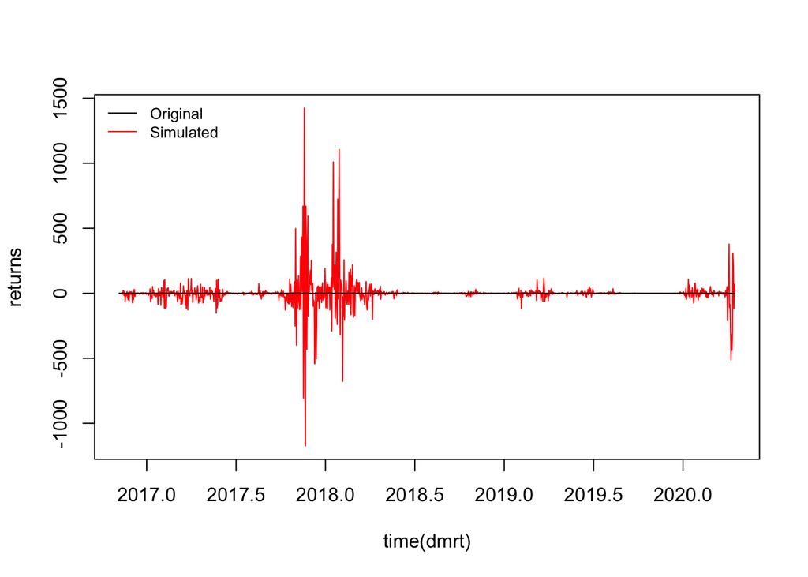

```r
plot(Y_state~time(dmrt),data=sim1.sim,type='l',col="red",ylab="returns")
lines(dmrt,type='l')
legend("topleft",legend=c("Original","Simulated"),col=c("black","red"),
       cex=0.8,lty=1,bty="n")
```

### Filtering for simulated data

Notice the simulated data is much more volatile than the actual demeaned return for Nasdaq-100 index. Therefore, we need to check whether we can successfully filter and re-estimate parameters for this simulated data.

```r
# Filtering object for simulated data
sim1.filt <- pomp(sim1.sim,
covar=covariate_table(
time=c(timezero(sim1.sim),time(sim1.sim)),
covaryt=c(obs(sim1.sim),NA),
times="time"),
statenames=ndx_statenames,
paramnames=ndx_paramnames,
rprocess=discrete_time(
step.fun=Csnippet(ndx_rproc.filt),delta.t=1)
)
# Setting up computational coefficients
run_level <- 3
ndx_Np <- switch(run_level, 100, 1e3, 2e3)
ndx_Nmif <- switch(run_level, 10, 100, 200)
ndx_Nreps_eval <- switch(run_level, 4, 10, 20)
ndx_Nreps_local <- switch(run_level, 10, 20, 20)
ndx_Nreps_global <- switch(run_level, 10, 20, 100)
cores <- as.numeric(Sys.getenv('SLURM_NTASKS_PER_NODE', unset=NA))
if(is.na(cores)) cores <- detectCores()
registerDoParallel(cores)
registerDoRNG(12345678)
# Filtering on simulated data
stew(file=sprintf("pf1-%d.rda",run_level),{
t.pf1 <- system.time(
pf1 <- foreach(i=1:ndx_Nreps_eval,
.packages='pomp') %dopar% pfilter(sim1.filt,Np=ndx_Np))
})
(L.pf1 <- logmeanexp(sapply(pf1,logLik),se=TRUE))
```

[output not shown]